# Homework 1

Author

Jasper Day

Published

June 6, 2022

# 1 Manipulating Vectors (1D images)

```julia
using Images
```

## 1.1 Make a random vector of length 10:

```julia
random_vect = rand(10)
```

```
10-element Vector{Float64}:
 0.9827024725034592
 0.23351703378467137
 0.566013192204552
 0.5033260361871896
 0.29450854009628125
 0.4391106920029324
 0.9449099759555715
 0.3454579621531365
 0.8143944219882098
 0.6890101286912893
```

## 1.2 `mean` and `demean`

> Make a function `mean` using a `for` loop, which computes the mean of a vector

```julia
function mean(x)
    sumph = 0
    for i in x
        sumph += i
    end
    sumph /= length(x)
    return sumph
end
```

```
mean (generic function with 1 method)
```

Testing our function:

```julia
@show mean([1,2,3]);
```

```
mean([1, 2, 3]) = 2.0
```

> Define `m` to be the mean of `random_vect`:

```julia
m = mean(random_vect)
```

```
0.5812950455567293
```

> A new function `demean` takes a vector `x` and subtracts the mean from each value in `x`.

```julia
function demean(x)
    return copy(x) .- mean(x)
end
```

```
demean (generic function with 1 method)
```

The mean of `demean(random_vect)` should therefore be 0:

```julia
mean(demean(random_vect))
```

```
1.1102230246251566e-17
```

The answer is just about machine $\epsilon$, which is nice.

## 1.3 `create_bar()`

> Generate a vector of 100 zeros. Change the center 20 to 1.

```julia
function create_bar()
    barvec = zeros(100)
    barvec[40:60] .= 1
    return barvec
end
```

```
create_bar (generic function with 1 method)
```

## 1.4 `vecvec_to_matrix` and the reverse

> Write a function that turns a `Vector` of `Vector`s into a matrix:

```julia
function vecvec_to_matrix(vecvec)
    tempmat = Matrix{typeof(vecvec[1][1])}(undef, length(vecvec), length(vecvec[1]))
    for i in 1:length(vecvec)
        tempmat[:,i] = vecvec[i]
    end
    return tempmat
end
```

```
vecvec_to_matrix (generic function with 1 method)
```

And the reverse:

```julia
function matrix_to_vecvec(matrix)
    newVec = Vector{Vector{typeof(matrix[1])}}(undef, size(matrix)[2])
    for i in 1:size(matrix)[2]
        newVec[i] = matrix[:,i]
    end
    return newVec
end
```

```
matrix_to_vecvec (generic function with 1 method)
```

Testing:

```julia
@show vecvec_to_matrix([[6 7], [8 9]]);
@show matrix_to_vecvec([6 7; 8 9]);
```

```
vecvec_to_matrix([[6 7], [8 9]]) = [6 8; 7 9]
```

```
matrix_to_vecvec([6 7; 8 9]) = [[6, 8], [7, 9]]
```

This is the best solution I could find to keep the types consistent. It feels a bit awkward to have to explicitly declare the types, but that’s fine. It’s also going to be faster than using a mutating function like `push!` or `append!`, since we give the vectors a full size when we create them, so no memory reallocation ever has to occur.

Anyway…

## 1.5 colored_line

```julia
# Definitions from homework notebook
colored_line(x::Vector{<:Real}) = Gray.(Float64.((hcat(x)')))
colored_line(x::Any) = nothing
example_vector = [0.5, 0.4, 0.3, 0.2, 0.1, 0.0, 0.7, 0.0, 0.7, 0.9]
display(colored_line(example_vector));
```

```julia
display(colored_line(random_vect))
```

```julia
display(colored_line(create_bar()))
```

# 2 Manipulating Images

> In this exercise we will get familiar with matrices (2D arrays) in Julia, by manipulating images. Recall that in Julia images are matrices of `RGB` color objects.

> Let’s load a picture of Philip again.

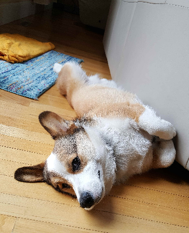

```julia
philip_file = let
    original = load(download("https://i.imgur.com/VGPeJ6s.jpg"))
    original[1:8:size(original)[1], 1:8:size(original)[2]]
end
```

## 2.1 `Mean Colors`

> Write a function **`mean_colors`** that accepts an object called `image`. It should calculate the mean (average) amounts of red, green and blue in the image and return a tuple `(r, g, b)` of those means.

```julia
function mean_colors(image)
    avgrgb = sum(philip_file) ./ length(philip_file)
    # Honestly you could stop here. Not sure why this all needs to be a whole function.
    return (avgrgb.r, avgrgb.b, avgrgb.b)
end
```

```
mean_colors (generic function with 1 method)
```

## 2.2 Quantizing numbers

> Look up the documentation on the `floor` function. Use it to write a function `quantize(x::Number)` that takes in a value $x$ (which you can assume is between 0 and 1) and “quantizes” it into bins of width 0.1. For example, check that 0.267 gets mapped to 0.2.

```julia
quantize(x::Number) = floor(10x)/10
@show quantize(0.267)
@show quantize(0.91)
```

```
quantize(0.267) = 0.2
quantize(0.91) = 0.9
```

```
0.9
```

## 2.3 A second method:

> Write the second **method** of the function `quantize`, i.e. a new *version* of the function with the *same* name. This method will accept a color object called `color`, of the type `AbstractRGB`.

The method you write should return a new `RGB` object, in which each component ($r$, $g$ and $b$) are quantized.

```julia
quantize(x::AbstractRGB) = RGB(quantize(x.r), quantize(x.g), quantize(x.b))
```

```
quantize (generic function with 2 methods)
```

## 2.4 A third method:

> Write a method `quantize(image::AbstractMatrix)` that quantizes an image by quantizing each pixel in the image. (You may assume that the matrix is a matrix of color objects.)

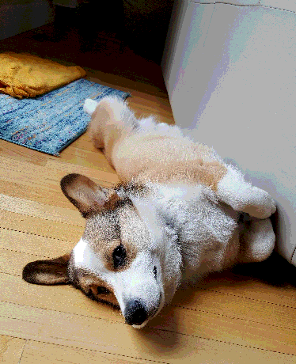

```julia
quantize(image::AbstractMatrix) = quantize.(image)
display(quantize(philip_file))
```

It surprisingly looks prety good, despite having half the color bandwidth of the original photo. With 10 buckets, though, you can definitely see some artefacting on the walls.

Let’s try larger buckets:

```julia
quantize(x::Number, buckets::Integer) = floor(buckets*x)/buckets
quantize(x::AbstractRGB, buckets::Integer) = RGB(quantize(x.r, buckets), quantize(x.g, buckets), quantize(x.b, buckets))
quantize(image::AbstractMatrix, buckets::Integer) = quantize.(image, buckets)
```

```
quantize (generic function with 6 methods)
```

Here’s Philip with 5 buckets:

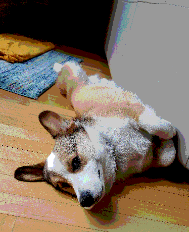

```julia
display(quantize(philip_file, 5))
```

Pretty exciting. I like the obvious lines in the shadow.

2 buckets:

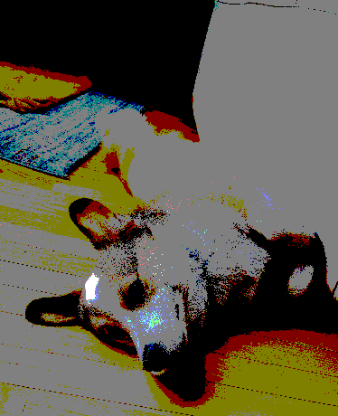

```julia
display(quantize(philip_file, 2))
```

Most of the picture is taken up by the rather bland `RGB(0.5,0.5,0.5)`. I liked 5 buckets better, I think.

## 2.5 Color inversion

> Write a function `invert` that inverts a color, i.e. sends $(r, g, b)$ to $(1 - r, 1-g, 1-b)$.

```julia
invert(x::AbstractRGB) = RGB(1-x.r, 1-x.g, 1-x.b)
```

```
invert (generic function with 1 method)
```

Jeez man.

Playing around with color inversion:

```julia
black = RGB(0.0,0.0,0.0)
invert(black)
```

[figure not shown]

It’s white.

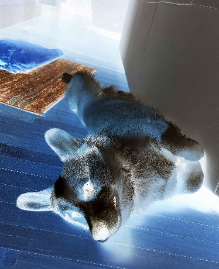

```julia
invert.(philip_file)
```

He looks rather ectoplasmic. The shadow in the background now reveals its secrets: it’s floorboards all the way back!

## 2.6 Noisify

> Write a function `noisify(x::Number, s)` to add randomness of intensity $s$ to a value $x$, i.e. to add a random value between $-s$ and $+s$ to $x$. If the result falls outside the range $(0, 1)$ you should “clamp” it to that range. (Note that Julia has a `clamp` function, but you should write your own function `myclamp(x)`.)

```julia
using Distributions
```

```
WARNING: using Distributions.mean in module Main conflicts with an existing identifier.
```

```julia
myclamp(x::Number) = x>1 ? 1 : (x<0 ? 0 : x)
noisifyp(x::Number, s) = myclamp(x + 2s*(rand()-0.5))
# That ^ works but I don't like it.
noisify(x::Number, s) = myclamp(x + rand(Uniform(-s,s)))
# I like that a little more but it may actually be slower.
noisifyp(x::AbstractRGB, s) = RGB(noisifyp(x.r, s), noisifyp(x.g, s), noisifyp(x.b, s))
noisify(x::AbstractRGB, s) = RGB(noisify(x.r, s), noisify(x.g, s), noisify(x.b, s))
noisifyp(x::AbstractMatrix, s) = noisifyp.(x, s)
noisify(x::AbstractMatrix, s) = noisify.(x, s);
```

Interestingly, the story of the two different noisifies appears to be a story of making a solution *worse* in an attempt to make it more elegant. It’s much worse, apparently, to take a random number from a uniform distribution across the desired range than to simply multiply `rand()` to change it into the desired range. Probably this is because the `rand(Uniform(-s, s))` calls two different functions, and who knows how optimized the function for the uniform distribution is. `rand()`, on the other hand, can be super optimized, so the multiplication and subtraction doesn’t add too much cost.

I found that `noisifyp` on the picture of Philip, with a noise level of 1, tended to run in 4 seconds or less, even with 8% compilation time. The best I could get out of `noisify` was 4.3 seconds, with upper bounds closer to 5 seconds. Sometimes the clunkier solution is actually faster.

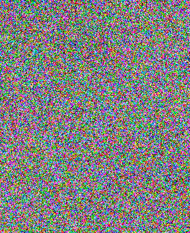

```julia
noisifyp(philip_file, 10)
```

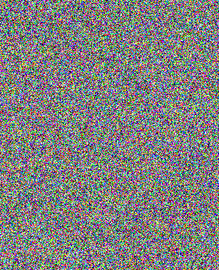

```julia
noisifyp(philip_file, 20)
```

```julia
decimate(image, ratio=5) = image[1:ratio:end, 1:ratio:end]
```

```
decimate (generic function with 2 methods)
```

# 3 Convolutions

> As we have seen in the videos, we can produce cool effects using the mathematical technique of >**convolutions**. We input one image $M$ and get a new image $M'$ back.

> Conceptually we think of $M$ as a matrix. In practice, in Julia it will be a `Matrix` of color objects, and we may need to take that into account. Ideally, however, we should write a **generic** function that will work for any type of data contained in the matrix.

> A convolution works on a small **window** of an image, i.e. a region centered around a given point $(i, j)$. We will suppose that the window is a square region with odd side length $2\ell + 1$, running from $-\ell, \ldots, 0, \ldots, \ell$.

> The result of the convolution over a given window, centred at the point $(i, j)$ is a *single number*; this number is the value that we will use for $M'_{i, j}$. (Note that neighbouring windows overlap.)

> To get started let’s restrict ourselves to convolutions in 1D. So a window is just a 1D region from $-\ell$ to $\ell$.

> Let’s create a vector `v` of random numbers of length `n=100`.

```julia
n = 100
v = rand(n)
colored_line(v)
```

## 3.1 Boundary conditions

> We need to decide how to handle the **boundary conditions**, i.e. what happens if we try to access a position in the vector `v` beyond `1:n`. The simplest solution is to assume that $v_{i}$ is 0 outside the original vector; however, this may lead to strange boundary effects.

> A better solution is to use the *closest* value that is inside the vector. Effectively we are extending the vector and copying the extreme values into the extended positions. (Indeed, this is one way we could implement this; these extra positions are called **ghost cells**.)

> Write a function `extend(v, i)` that checks whether the position $i$ is inside `1:n`. If so, return the $i$th component of `v`; otherwise, return the nearest end value.

```julia
extend(v, i) = i in 1:length(v) ? v[i] : (i < 1 ? first(v) : last(v))
```

```
extend (generic function with 1 method)
```

## 3.2 1D blur

> Write a function `blur_1D(v, l)` that blurs a vector `v` with a window of length `l` by averaging the elements within a window from $-\ell$ to $\ell$. This is called a **box blur**.

```julia
blur_1D(v,l) = [sum([extend(v,j + i) for j in -l:l]) / (2l + 1) for i in 1:length(v)]
# Look how sexy. One line. No silly functions like "copy." I liiiike it. Even though all it can do is the box average :)
```

```
blur_1D (generic function with 1 method)
```

In $\text{\LaTeX}$, that line of code translates to:

$$v'_i = \frac{\sum_{j = -\ell}^{\ell}v_{j+i}}{2\ell+1}$$

Not sure if that makes it any clearer.

```julia
colored_line(example_vector)
```

```julia
colored_line(blur_1D(example_vector, 2))
```

## 3.3 Different size box_blurs

No interactive controls here. Just a couple of well-chosen examples.

```julia
l_box = 0
colored_line(blur_1D(v,l_box))
```

```julia
l_box = 2
colored_line(blur_1D(v,l_box))
```

```julia
l_box = 4
colored_line(blur_1D(v,l_box))
```

```julia
l_box = 10
colored_line(blur_1D(v,l_box))
```

## 3.4 General 1D Convolutions

> The box blur is a simple example of a **convolution**, i.e. a linear function of a window around each point, given by

$$v'_{i} = \sum_{n}\,v_{i - n}\,k_{n}$$

> where $k$ is a vector called a **kernel**.

> Again, we need to take care about what happens if $v_{i -n }$ falls off the end of the vector.

> Write a function `convolve_vector(v, k)` that performs this convolution. You need to think of the vector $k$ as being *centred* on the position $i$. So $n$ in the above formula runs between $-\ell$ and $\ell$, where $2\ell + 1$ is the length of the vector $k$. You will need to do the necessary manipulation of indices.

```julia
convolve_vector(v,k) = [sum([extend(v,i-(n-1 - length(k)÷2)) * k[n] # assume k is not an offset matrix
        for n in 1:length(k)])
    for i in 1:length(v)]
```

```
convolve_vector (generic function with 1 method)
```

Also neatly fits into (almost) one line. I like Julia more and more the more I use it. Although my obsession with single-line functions is somewhat to the detriment of the readability of my code.

```julia
test_convolution = let
    v = [1, 10, 100, 1000, 10000]
    k = [2, 1, 0, 1, 3]
    convolve_vector(v, k)
end
```

```
5-element Vector{Int64}:
   214
  2104
 21013
 30130
 31300
```

**Note**

When using $\sum_{n}\,v_{i - n}\,k_{n}$, the kernel is basically flipped 180°. You can avoid this behavior by using $\sum_{n}\,v_{i + n}\,k_{n}$, but you shouldn’t.

## 3.5 Gaussian kernel

The definition of a Gaussian kernel in 1D is:

$$G(x) = \frac{1}{\sqrt{2\pi \sigma^2}} \exp\left({\frac{-x^2}{2\sigma^2}}\right)$$

> We need to **sample** (evaluate) this at each pixel in a rigion of size $n^2$, and then **normalize** so that the sum of the resulting kernel is 1.

**Note**

Rather than taking $\sigma=1$ for simplicity, I chose to allow any value of $\sigma$.

Also, there seems to be a typo in the instructions. We should be evaluating over $2n+1$, not $n^2$.

```julia
normalize(v) = [v[i] / sum(v) for i in 1:length(v)]

function gaussian_kernel(n::Integer, σ=1)
    G(x) = 1/√(2π*σ^2) * exp(-x^2/(2σ^2))
    new_vec = zeros(n)
    [new_vec[i] = G(i-1 - n÷2) for i in 1:n]
    return normalize(new_vec)
end
```

```
gaussian_kernel (generic function with 2 methods)
```

Seems to work. 🤞

```julia
gaussian_kernel_size_1D = 5

test_gauss_1D_a = let
    v = rand(20)
    k = gaussian_kernel(gaussian_kernel_size_1D)

    if k !== missing
        convolve_vector(v, k)
    end
end
```

```
20-element Vector{Float64}:
 0.6128542497065008
 0.5186034430596811
 0.5372194280082668
 0.4713691462679216
 0.35370291693454403
 0.3532706050294181
 0.5461461212015242
 0.6872961055423357
 0.6528729325348471
 0.5959611796394492
 0.6430531892648421
 0.6320452254327004
 0.512943091287473
 0.42294081010027856
 0.47313256349785776
 0.5610035386788762
 0.5626955062503793
 0.64101717209861
 0.792577764458673
 0.8449002553443036
```

You can get some very pretty gradients by increasing the standard deviation of the gaussian kernel. For example:

```julia
nice_gradient = let
    v = rand(20)
    k = gaussian_kernel(10, 2)
    convolve_vector(v,k)
end

colored_line(nice_gradient)
```

# 4 Convolutions of Images

With 2D images, the convolution is given by a **kernel matrix** $K$:

$$M'_{i,j} = \sum_{k,l} \, M_{i-k,j-l} \, K_{k,l}$$

where the sum is over the possible values of $k$ and $l$ in the window. The window is centered at $(i,j)$. The convolution is often notated with a star $*$:

$$M' = M * K$$

## 4.1 Extend_matrix:

> Write a function extend_mat that takes a matrix M and indices i and j, and returns the closest element of the matrix.

```julia
extend_mat(M::AbstractMatrix, i, j) = M[clamp(i, 1, size(M)[1]), clamp(j, 1, size(M)[2])];
```

Let’s extend Philip:

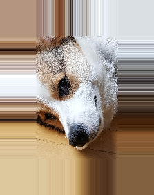

```julia
let
    philip_head = philip_file[250:430,110:230]
    [extend_mat(philip_head, i, j) for (i,j) in Iterators.product(-50:size(philip_head,1)+51, (-50:size(philip_head,2)+51))]
end
```

More single line functions. Are they beautiful or annoying? That’s your choice.

Now (finally!) the meat of the first homework:

## 4.2 `Convolve_image`

> Implement a function convolve_image(M, K).

```julia
function convolve_image(M::AbstractMatrix, K::AbstractMatrix)
    NewMat = zeros(size(M))
    adjustx = size(K)[1] ÷ 2 + 1
    adjusty = size(K)[2] ÷ 2 + 1
    for (i,j) in Iterators.product(1:size(M)[1], 1:size(M)[2]) ## for each M_{i,j}
        NewMat[i,j] = sum([
            extend_mat(M, i-k - adjustx, j-l - adjusty) .* K[k,l]
            for (k,l) in Iterators.product(1:size(K)[1], 1:size(K)[2])
        ])
    end
    return NewMat
end
```

```
convolve_image (generic function with 1 method)
```